# Coding 2 - PSL 598, Fall 2022

Alejandro Pimentel (netID ap41,UIN 659282110)

```r
library(glmnet)
library(pls)
```

## Part I: Implement Lasso

### One-variable Lasso

The `one_var_lasso` function below takes the following inputs:

$$\mathbf{r}=(r_1, \dots, r_n)^t, \quad
\mathbf{z} = (z_1, \dots, z_n)^t, \quad \lambda > 0$$
and solves the following one-variable Lasso problem:
$$\min_{b} \frac{1}{2n} \sum_{i=1}^n (r_i- b z_{i} )^2 + \lambda | b |
= \min_{b} \frac{1}{2n} \| \mathbf{r} - b \cdot \mathbf{z}\|^2 +
\lambda | b |.$$

```r
one_var_lasso = function(r, z, lam) {

  n = length(r)

  z_len = t(z) %*% z
  a_num = t(r) %*% z

  a = a_num / z_len
  lam_ = (2*n*lam) / z_len

  ## derivation cases
  x = a + lam_ / 2
  if(a > lam_ / 2) {
    x = a - lam_ / 2
  }

  if(abs(a) <= lam_ / 2) {
    x = 0
  }

  ## select same sign as a
  if((a < 0 && x > 0) || (a > 0 && x < 0)) {
    x = x * -1
  }

  return(x)
}
```

### The CD Algorithm

Function `MyLasso` implements the **Coordinate Descent (CD)** algorithm by repeatedly calling `one_var_lasso`.

In the CD algorithm, at each iteration, we solve a one-variable Lasso problem for $\beta_j$ while holding the other $(p-1)$ coefficients at their current values:
$$\min_{\beta_j} \sum_{i=1}^n (\color{blue}{y_i - \sum_{k \ne j} x_{ik}
\beta_k} - x_{ij} \beta_j)^2 + \lambda \sum_{k \ne j} | \beta_k| +
\lambda | \beta_j|,$$
which is equivalent to solving the following one-variable Lasso problem
$$\min_{\beta_j} \sum_{i=1}^n (\color{blue}{r_i}- x_{ij} \beta_j)^2 +
\lambda | \beta_j|, \quad \color{blue}{r_i} = y_i - \sum_{k \ne j}
x_{ik} \beta_k.$$

```r
MyLasso = function(X, y, lam.seq, maxit = 100) {

    # Input
    # X: n-by-p design matrix without the intercept
    # y: n-by-1 response vector
    # lam.seq: sequence of lambda values (arranged from large to small)
    # maxit: number of updates for each lambda

    # Output
    # B: a (p+1)-by-length(lam.seq) coefficient matrix
    #    with the first row being the intercept sequence

    n = length(y)
    p = dim(X)[2]
    nlam = length(lam.seq)
    B = matrix(0, ncol = nlam, nrow = (p+1))
    rownames(B) = c("Intercept", colnames(X))

    # new.X = centered & scaled X;
    ones = rep(1, n)
    X_means = colMeans(X)
    Xn_means = ones %*% t(X_means)
    X_centered = X - Xn_means

    X_sds = apply(X, 2, sd)
    Xn_sds = ones %*% t(X_sds)
    new.X = X_centered / Xn_sds

    # Initialize coef vector b and residual vector r
    b = rep(0, p)
    r = y

    # Triple nested loop
    for (m in 1:nlam) {
      for (step in 1:maxit) {
        for (j in 1:p) {
          r = r + (new.X[, j] * b[j])
          b[j] = one_var_lasso(r, new.X[, j], lam.seq[m])
          r = r - new.X[, j] * b[j]
        }
      }
      B[-1, m] = b
    }

    # scale back the coefficients;
    # update the intercepts stored in B[1, ]
    B[-1, ] = B[-1, ] / X_sds
    inter_=colSums(B[-1,] * -X_means)
    B[1,] = mean(y) + inter_

    return(B)
}
```

### Test the Lasso Function

We test `MyLasso` function on data set `Coding2_Data.csv` with the following lambda sequence. Data set has 13 predictors, `V1` to `V13`, and one response vector `Y`.

```r
myData = read.csv("Coding2_Data.csv")
X = as.matrix(myData[, -14])
y = myData$Y
lam.seq = exp(seq(-1, -8, length.out = 80))
myout = MyLasso(X, y, lam.seq)
```

- Next we check the accuracy of the function against the output from `glmnet`. The maximum difference between the two coefficient matrices should be less than 0.005.

```r
lasso.fit = glmnet(X, y, alpha = 1, lambda = lam.seq)
max(abs(coef(lasso.fit) - myout))
```

```
## [1] 0.00456362
```

- Below we show a path plot for the 13 non-intercept coefficients obtained with `MyLasso` function along the lambda values in log scale.

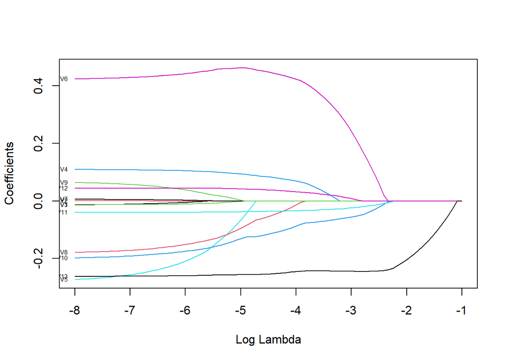

```r
x.index = log(lam.seq)
beta = myout[-1, ]  # beta is a 13-by-80 matrix
matplot(x.index, t(beta),
        xlim = c(min(x.index), max(x.index)),
        lty = 1,
        xlab = "Log Lambda",
        ylab = "Coefficients",
        type="l",
        lwd = 1)
# You can add variable names to each path
var.names = colnames(X)
nvar = length(var.names)
xpos = rep(min(x.index), nvar)
ypos = beta[, ncol(beta)]
text(xpos, ypos, var.names, cex=0.5, pos=2)
```

Below, the plot from `glmnet` fit is very similar to the one using `MyLasso`.

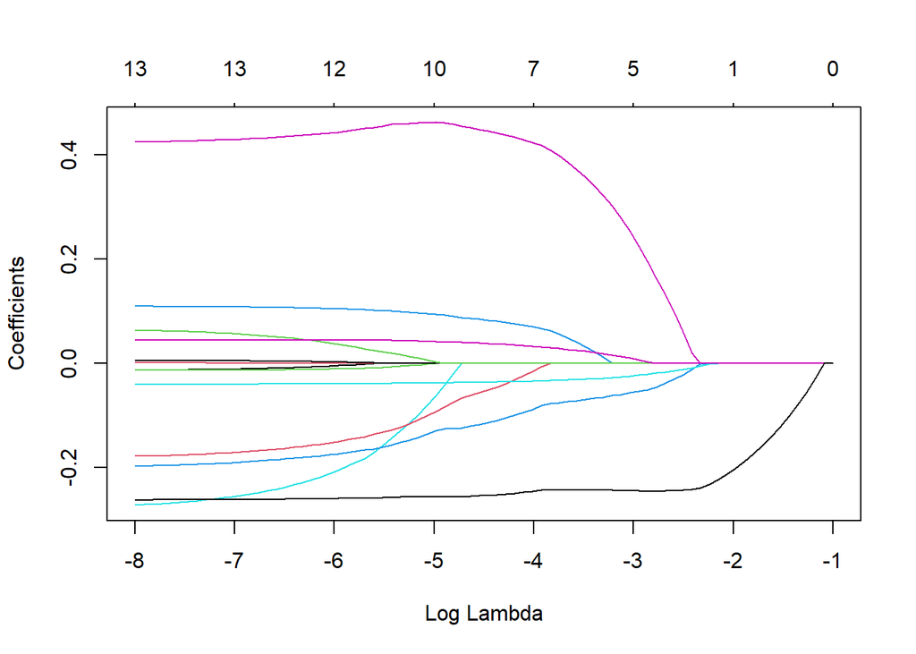

```r
plot(lasso.fit, xvar = "lambda")
```

## Part II: Simulation Study

```r
# Set a seed to have a stable generation of random numbers
uin_4 = 2110
set.seed(uin_4)
```

First, we define functions to repeat **seven** different procedures multiple times in a loop.

- **Full**: linear regression model using all features

```r
full_model = function(data, test.ids) {

  mse = rep(NaN, dim(test.ids)[2])
  for(i in 1:dim(test.ids)[2]) {
    test.id = test.ids[, i]
    full.model = lm(Y ~ ., data = data[-test.id, ])
    Ytest.pred = predict(full.model, newdata = myData[test.id, ])
    mse[i] = mean((myData$Y[test.id] - Ytest.pred)^2)
  }

  return(mse)
}
```

- **Ridge.min** and **Ridge.1se**: Ridge regression using `lambda.min` or `lambda.1se`

```r
ridge_reg = function(X_data, Y_data, test.ids) {

  mylasso.lambda.seq = exp(seq(-10, 1, length.out = 100))

  mse = list(
    lam_min = rep(NaN, dim(test.ids)[2]),
    lam_1se = rep(NaN, dim(test.ids)[2])
  )

  for(i in 1:dim(test.ids)[2]) {
    test.id = test.ids[, i]
    cv.out = cv.glmnet(X_data[-test.id, ], Y_data[-test.id], alpha = 0,
                       lambda = mylasso.lambda.seq)

    best.lam = cv.out$lambda.min
    Ytest.pred = predict(cv.out, s = best.lam, newx = X_data[test.id, ])
    mse$lam_min[i] = mean((Y_data[test.id] - Ytest.pred)^2)

    best.lam = cv.out$lambda.1se
    Ytest.pred = predict(cv.out, s = best.lam, newx = X_data[test.id, ])
    mse$lam_1se[i] = mean((Y_data[test.id] - Ytest.pred)^2)
  }

  return(mse)
}
```

- **Lasso.min** and **Lasso.1se**: Lasso using `lambda.min` or `lambda.1se`
- **L.Refit**: Refit the model selected by Lasso using `lambda.1se`

```r
lasso_reg = function(data, test.ids) {

  X_data = data.matrix(data[,-1])
  Y_data = data[,1]

  mse = list(
    lam_min = rep(NaN, dim(test.ids)[2]),
    lam_1se = rep(NaN, dim(test.ids)[2]),
    refit = rep(NaN, dim(test.ids)[2])
  )

  for(i in 1:dim(test.ids)[2]) {
    test.id = test.ids[, i]
    cv.out = cv.glmnet(X_data[-test.id, ], Y_data[-test.id], alpha = 1)
    best.lam = cv.out$lambda.min
    Ytest.pred = predict(cv.out, s = best.lam, newx = X_data[test.id, ])
    mse$lam_min[i] = mean((Y_data[test.id] - Ytest.pred)^2)

    best.lam = cv.out$lambda.1se
    Ytest.pred = predict(cv.out, s = best.lam, newx = X_data[test.id, ])
    mse$lam_1se[i] = mean((Y_data[test.id] - Ytest.pred)^2)

    # Lasso refit
    mylasso.coef = predict(cv.out, s = best.lam, type = "coefficients")
    var.sel = row.names(mylasso.coef)[which(mylasso.coef != 0)[-1]]

    mylasso.refit = lm(Y ~ ., data[-test.id, c("Y", var.sel)])
    Ytest.pred = predict(mylasso.refit, newdata = data[test.id, ])
    mse$refit[i] = mean((Ytest.pred - Y_data[test.id])^2)
  }

  return(mse)
}
```

- **PCR**: principle components regression with the number of components chosen by 10-fold cross validation

```r
pcr_reg = function(data, test.ids) {

  mse = rep(NaN, dim(test.ids)[2])

  for(i in 1:dim(test.ids)[2]) {
    test.id = test.ids[, i]
    mypcr = pcr(Y ~ ., data= data[-test.id, ], validation="CV", scale=TRUE)
    CVerr = RMSEP(mypcr)$val[1, , ]
    adjCVerr = RMSEP(mypcr)$val[2, , ]
    best.ncomp = which.min(CVerr) - 1

    if (best.ncomp==0) {
      Ytest.pred = mean(data$Y[-test.id])
    } else {
      Ytest.pred = predict(mypcr, data[test.id,], ncomp=best.ncomp)
    }
    mse[i] = mean((Ytest.pred - data$Y[test.id])^2)
  }

  return(mse)
}
```